# Predicting Average Salary

Piotr Wieczorek

2024-02-21

```r
rm(list=ls())
```

## Goal of the project

##### This project aims to create a model to predict average salary based on following attributes:

1. Description (company field)
2. Ratings
3. Highly_rated_for
4. Critically_rated_for
5. Total_reviews
6. Interviews_taken
7. Total_jobs_available
8. Total_benefits

## Libraries

```r
library(tidyverse)
library(caret)
library(ggthemr)
library(DT)
library(naniar)
library(missForest)
library(janitor)
library(gridExtra)
library(datawizard)
library(car)
library(lmtest)
library(MLmetrics)
library(kableExtra)
library(randomForest)
library(fastDummies)
```

## Cleaning and exploring the data

```r
df <- read.csv("companies.csv")
```

```r
df %>%
  head()%>%
  kable(align = "c") %>%
    kable_styling(position = "center") %>%
    scroll_box(width = "100%",height="100%")
```

| Company_name | Description | Ratings | Highly_rated_for | Critically_rated_for | Total_reviews | Avg_salary | Interviews_taken | Total_jobs_available | Total_benefits |
| --- | --- | --- | --- | --- | --- | --- | --- | --- | --- |
| TCS | IT Services & Consulting \| 1 Lakh+ Employees \| Public \| 56 years old \| Mumbai +339 more | 3.8 | Job Security, Work Life Balance | Promotions / Appraisal, Salary & Benefits | 73.1k | 856.9k | 6.1k | 847 | 11.5k |
| Accenture | IT Services & Consulting \| 1 Lakh+ Employees \| Public \| 35 years old \| Dublin +173 more | 4.0 | Company Culture, Skill Development / Learning, Job Security |  | 46.4k | 584.6k | 4.3k | 9.9k | 7.1k |
| Cognizant | IT Services & Consulting \| 1 Lakh+ Employees \| Forbes Global 2000 \| 30 years old \| Teaneck. New Jersey. +156 more | 3.9 | Skill Development / Learning | Promotions / Appraisal | 41.7k | 561.5k | 3.6k | 460 | 5.8k |
| Wipro | IT Services & Consulting \| 1 Lakh+ Employees \| Public \| 79 years old \| Bangalore/Bengaluru +276 more | 3.8 | Job Security | Promotions / Appraisal, Salary & Benefits | 39.2k | 427.4k | 3.7k | 405 | 5k |
| Capgemini | IT Services & Consulting \| 1 Lakh+ Employees \| Public \| 57 years old \| Paris +139 more | 3.9 | Job Security, Work Life Balance, Skill Development / Learning | Promotions / Appraisal, Salary & Benefits | 34k | 414.4k | 2.8k | 719 | 4k |
| HDFC Bank | Banking \| 1 Lakh+ Employees \| Public \| 30 years old \| Mumbai +1531 more | 4.0 | Job Security, Skill Development / Learning | Promotions / Appraisal | 33.9k | 132.3k | 1.5k | 335 | 3.2k |

### Changing blank values to a category (“No critical rating”)

```r
df$Critically_rated_for = ifelse(df$Critically_rated_for == "", "No critical rating",df$Critically_rated_for)
```

### Fixing numerical columns

##### Numerical columns were read as character columns because of the “k” symbol which stands for “thousand” so the function below changes this notation by multiplying the value by a thousand whenever it occurs

```r
df[, c(6:10)] <- sapply(df[, c(6:10)], function(x) {
  ifelse(
    str_detect(x, "k"),
    as.numeric(str_replace(x, "k", "")) * 1000,
    as.numeric(x)
  )
})
```

### Changing character columns to factor columns

```r
df <- df %>%
  mutate_if(is.character,as.factor)
```

### Fixing the “Highly_rated_for” column

##### The function below selects only the first category of the description (it returns the first part of the string before the first occurence of the comma symbol)

```r
df$Highly_rated_for <- sapply(df$Highly_rated_for, function(x) {
  ifelse(str_detect(string=x,pattern = ","),
         str_split_i(x,pattern=",",i=1),
         as.character(x)
  )
})
```

### Fixing the “Critically_rated_for” column

##### The function below does the same thing as for the “Highly_rated_for” column

```r
df$Critically_rated_for <- sapply(df$Critically_rated_for, function(x) {
  ifelse(str_detect(string=x,pattern = ","),
         str_split_i(x,pattern=",",i=1),
         as.character(x)
  )
})
```

```r
df$Critically_rated_for <- as.factor(df$Critically_rated_for)
```

```r
df$Description <- trimws(str_split_i(df$Description,"\\|", i=1))
```

```r
df$Description <- as.factor(df$Description)
```

### Replacing blank values with NA

```r
df[df==""] <- NA
```

### NA values report

```r
naniar::miss_var_summary(df) %>%
  filter(n_miss>0)
```

```
## # A tibble: 5 × 3
##   variable             n_miss pct_miss
##   <chr>                 <int>    <dbl>
## 1 Total_jobs_available   3923    39.2
## 2 Interviews_taken        219     2.19
## 3 Highly_rated_for         92     0.92
## 4 Total_benefits           79     0.79
## 5 Avg_salary                2     0.02
```

### Replacing NA with 0 in the “Total_jobs_available column

```r
df$Total_jobs_available <- as.numeric(str_replace_all(str_replace_na(df$Total_jobs_available),"NA","0"))
```

```r
naniar::miss_var_summary(df) %>%
  filter(n_miss>0)
```

```
## # A tibble: 4 × 3
##   variable         n_miss pct_miss
##   <chr>             <int>    <dbl>
## 1 Interviews_taken    219     2.19
## 2 Highly_rated_for     92     0.92
## 3 Total_benefits       79     0.79
## 4 Avg_salary            2     0.02
```

```r
df$Highly_rated_for <- as.factor(df$Highly_rated_for)
```

### Unselecting the “Company_name” column

##### This column was dropped because it has too many categories to be included in the model

```r
df <- df %>%
  select(-c("Company_name"))
```

### Preparing the “Description” column for modeling purposes

##### This variable has a lot of categories so it was decided to choose only first ten categories (in terms of their share in the variable) and replace all other categories with “Other” in order to avoid near zero variables in the regression model

```r
DT::datatable(as.data.frame(janitor::tabyl(df,Description)) %>%
  arrange(desc(n)),editable = "cell")
```

|  | Description | n | percent |
| --- | --- | --- | --- |
| 1 | IT Services &amp; Consulting | 1299 | 0.1299 |
| 2 | Engineering &amp; Construction | 503 | 0.0503 |
| 3 | Auto Components | 460 | 0.046 |
| 4 | Industrial Machinery | 420 | 0.042 |
| 5 | Pharma | 384 | 0.0384 |
| 6 | Education &amp; Training | 350 | 0.035 |
| 7 | Healthcare | 349 | 0.0349 |
| 8 | Financial Services | 293 | 0.0293 |
| 9 | Internet | 257 | 0.0257 |
| 10 | Software Product | 254 | 0.0254 |

[output cut: 221 more lines]

```r
df$Description <- case_when(
    df$Description %in% c("IT Services & Consulting", "Engineering & Construction",
                       "Auto Components", "Industrial Machinery", "Pharma",
                       "Education & Training", "Healthcare", "Financial Services",
                       "Internet", "Software Product") ~ df$Description,
    TRUE ~ "Other")
```

```r
df$Description <- as.factor(df$Description)
```

```r
naniar::miss_var_summary(df) %>%
  filter(n_miss >0)
```

```
## # A tibble: 4 × 3
##   variable         n_miss pct_miss
##   <chr>             <int>    <dbl>
## 1 Interviews_taken    219     2.19
## 2 Highly_rated_for     92     0.92
## 3 Total_benefits       79     0.79
## 4 Avg_salary            2     0.02
```

## Modeling part

### Data partition

```r
set.seed(321)

train_percentage <- 0.7


num_rows <- nrow(df)


train_indices <- sample(seq_len(num_rows), size = round(train_percentage * num_rows))

# Create the training set
train_set <- df[train_indices, ]


test_set <- df[-train_indices, ]
```

```r
naniar::miss_var_summary(train_set) %>%
  filter(n_miss > 0)
```

```
## # A tibble: 4 × 3
##   variable         n_miss pct_miss
##   <chr>             <int>    <dbl>
## 1 Interviews_taken    163   2.33
## 2 Highly_rated_for     66   0.943
## 3 Total_benefits       53   0.757
## 4 Avg_salary            1   0.0143
```

```r
naniar::miss_var_summary(test_set) %>%
  filter(n_miss > 0)
```

```
## # A tibble: 4 × 3
##   variable         n_miss pct_miss
##   <chr>             <int>    <dbl>
## 1 Interviews_taken     56   1.87
## 2 Highly_rated_for     26   0.867
## 3 Total_benefits       26   0.867
## 4 Avg_salary            1   0.0333
```

### Dropping remaining NA values in both train and test set

```r
train_set <- train_set %>%
  drop_na()

test_set <- test_set %>%
  drop_na()
```

### Fixing the “Avg_salary” column

##### Apparently there was a mistake in the dataset because some observations exhibit values of “Avg_salary” such as 5,3,10 etc. so it was decided to exclude all observations where the “Avg_salary” is below 500 from both train and test set

##### Visualizing “Avg_salary” before the changes

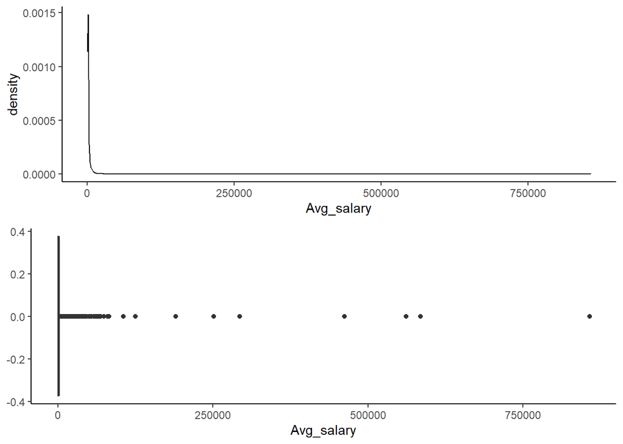

```r
grid.arrange(
  train_set %>%
    ggplot(aes(x=Avg_salary)) +
    geom_density() +
    theme_classic(),

train_set %>%
  ggplot(aes(x=Avg_salary)) +
  geom_boxplot() + theme_classic()
)
```

```r
train_set <- train_set %>%
  filter(Avg_salary > 500)

test_set <- test_set %>%
  filter(Avg_salary > 500)
```

```r
quantile(train_set$Avg_salary,c(seq(0,1,by=0.05)))
```

```
##       0%       5%      10%      15%      20%      25%      30%      35%
##    501.0    539.0    577.0    618.0    667.0    719.0    771.0    825.0
##      40%      45%      50%      55%      60%      65%      70%      75%
##    892.2    973.0   1100.0   1200.0   1300.0   1500.0   1700.0   2100.0
##      80%      85%      90%      95%     100%
##   2600.0   3500.0   4900.0   8400.0 856900.0
```

##### It was also decided to exclude the right-tailed outliers from the data set for this variable by excluding all observations where “Avg_salary” is higher than 8400 (which was the 95th percentile in the train set) from both train and test set

```r
train_set <- train_set %>%
  filter(Avg_salary <= 8400)


test_set <- test_set %>%
  filter(Avg_salary <= 8400)
```

##### Visualizing “Avg_salary” after the changes

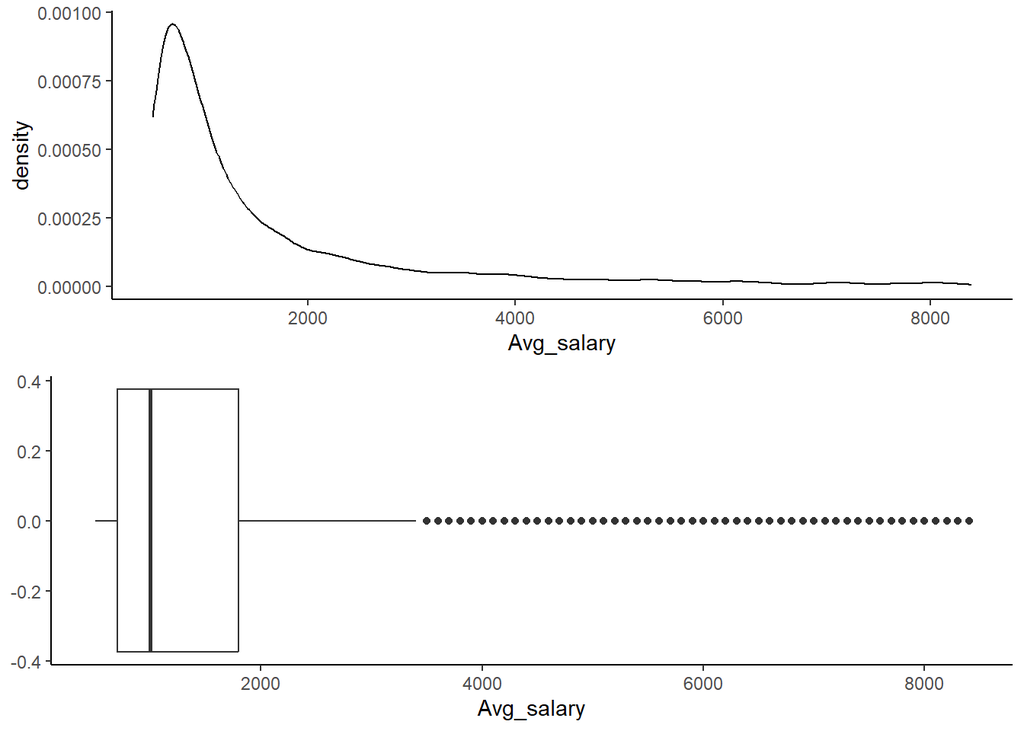

```r
grid.arrange(
  train_set %>%
    ggplot(aes(x=Avg_salary)) +
    geom_density() +
    theme_classic(),


 train_set %>%
    ggplot(aes(x=Avg_salary)) +
    geom_boxplot() +
    theme_classic()
)
```

### Relationship between the dependent and independent variables

##### Correlation betwen the dependent and independent variables is positive for each pair

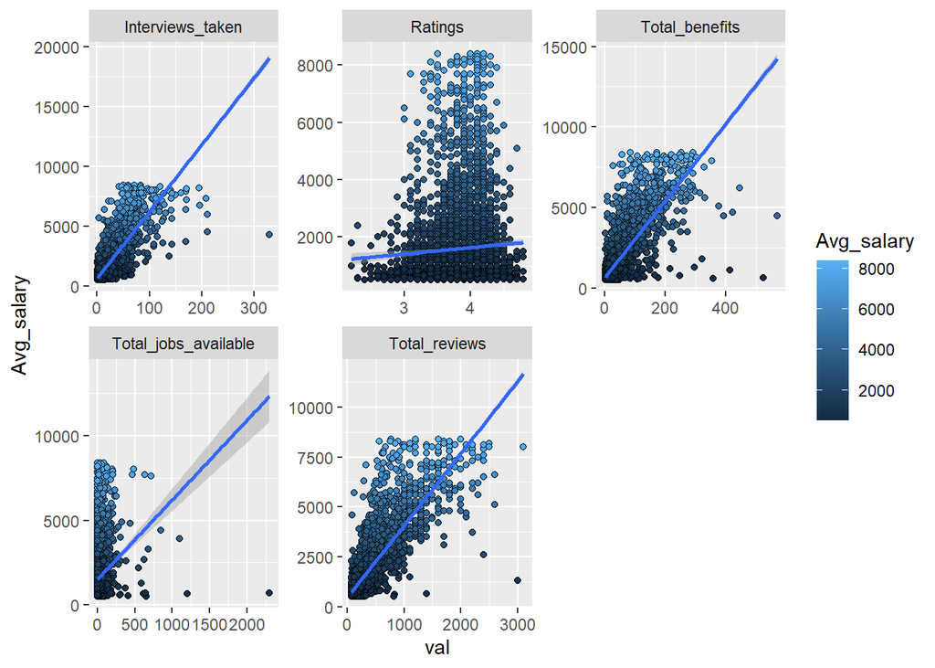

```r
train_set %>%
  gather(c("Total_reviews","Ratings","Interviews_taken","Total_jobs_available","Total_benefits"),key="key",value="val") %>%
  select(c("Avg_salary","key","val")) %>%
  ggplot(aes(x=val,y=Avg_salary ,fill=Avg_salary )) +
  geom_point(shape=21) +
  geom_smooth(method="lm")+
  facet_wrap(~key,scales="free")
```

```r
cor(train_set %>% select_if(is.numeric))
```

```
##                          Ratings Total_reviews Avg_salary Interviews_taken
## Ratings               1.00000000     0.1503449 0.05320496       0.02196277
## Total_reviews         0.15034490     1.0000000 0.84393822       0.78325021
## Avg_salary            0.05320496     0.8439382 1.00000000       0.80996842
## Interviews_taken      0.02196277     0.7832502 0.80996842       1.00000000
## Total_jobs_available -0.08445217     0.1414975 0.19616186       0.19768583
## Total_benefits        0.19412629     0.8778257 0.77609073       0.69193406
##                      Total_jobs_available Total_benefits
## Ratings                       -0.08445217      0.1941263
## Total_reviews                  0.14149746      0.8778257
## Avg_salary                     0.19616186      0.7760907
## Interviews_taken               0.19768583      0.6919341
## Total_jobs_available           1.00000000      0.1195382
## Total_benefits                 0.11953816      1.0000000
```

### Linear regression

#### First linear regression model

```r
mod1 <- lm(Avg_salary  ~., data=train_set)
```

```r
summary(mod1)
```

```
##
## Call:
## lm(formula = Avg_salary ~ ., data = train_set)
##
## Residuals:
##     Min      1Q  Median      3Q     Max
## -6959.9  -275.9   -68.3   175.8  5326.6
##
## Coefficients:
##                                                    Estimate Std. Error t value
## (Intercept)                                       736.13345  201.74783   3.649
## DescriptionEducation & Training                  -379.11591   76.03268  -4.986
## DescriptionEngineering & Construction            -288.31091   63.17571  -4.564
## DescriptionFinancial Services                      76.05699   70.71960   1.075
## DescriptionHealthcare                            -187.40171   70.25424  -2.667
## DescriptionIndustrial Machinery                   -84.85660   61.10813  -1.389
## DescriptionInternet                              -243.27445   74.28432  -3.275
## DescriptionIT Services & Consulting               163.20368   50.03885   3.262
## DescriptionOther                                 -176.39827   44.14956  -3.995
## DescriptionPharma                                -107.05846   64.96011  -1.648
## DescriptionSoftware Product                       186.45372   71.49118   2.608
## Ratings                                          -100.71725   32.80999  -3.070
## Highly_rated_forJob Security                       85.11057   36.74108   2.316
## Highly_rated_forPromotions / Appraisal            118.49016   39.93591   2.967
## Highly_rated_forSalary & Benefits                 -11.21589   49.36070  -0.227
## Highly_rated_forSkill Development / Learning     -144.98025   42.49898  -3.411
## Highly_rated_forWork Life Balance                 134.21393   39.66268   3.384
## Highly_rated_forWork Satisfaction                  41.65821   87.53070   0.476
## Critically_rated_forJob Security                  -29.54612  164.02927  -0.180
## Critically_rated_forNo critical rating             17.86390  148.64669   0.120
## Critically_rated_forPromotions / Appraisal        186.31445  149.36705   1.247
## Critically_rated_forSalary & Benefits             125.44775  161.65469   0.776
## Critically_rated_forSkill Development / Learning  208.68887  233.85260   0.892
## Critically_rated_forWork Life Balance             314.61321  195.29229   1.611
## Critically_rated_forWork Satisfaction             384.32845  211.63596   1.816
## Total_reviews                                       1.96072    0.07062  27.763
## Interviews_taken                                   23.76909    0.76672  31.001
## Total_jobs_available                                0.97465    0.16368   5.955
## Total_benefits                                      4.50248    0.43316  10.394
##                                                  Pr(>|t|)
```

[output cut: 20 more lines]

```
## Critically_rated_forPromotions / Appraisal       0.212327
## Critically_rated_forSalary & Benefits            0.437774
## Critically_rated_forSkill Development / Learning 0.372227
## Critically_rated_forWork Life Balance            0.107250
## Critically_rated_forWork Satisfaction            0.069436 .
## Total_reviews                                     < 2e-16 ***
## Interviews_taken                                  < 2e-16 ***
## Total_jobs_available                             2.79e-09 ***
## Total_benefits                                    < 2e-16 ***
## ---
## Signif. codes:  0 '***' 0.001 '**' 0.01 '*' 0.05 '.' 0.1 ' ' 1
##
## Residual standard error: 675.3 on 4723 degrees of freedom
## Multiple R-squared:  0.7933, Adjusted R-squared:  0.7921
## F-statistic: 647.3 on 28 and 4723 DF,  p-value: < 2.2e-16
```

#### Second linear regression model

```r
mod2 <- lm(formula = Avg_salary ~. -Critically_rated_for, data=train_set)
```

```r
summary(mod2)
```

```
##
## Call:
## lm(formula = Avg_salary ~ . - Critically_rated_for, data = train_set)
##
## Residuals:
##     Min      1Q  Median      3Q     Max
## -7030.3  -272.8   -72.0   166.0  5330.7
##
## Coefficients:
##                                               Estimate Std. Error t value
## (Intercept)                                   876.5947   141.9780   6.174
## DescriptionEducation & Training              -386.3379    76.3953  -5.057
## DescriptionEngineering & Construction        -304.6680    63.4419  -4.802
## DescriptionFinancial Services                  68.3280    71.0368   0.962
## DescriptionHealthcare                        -197.3059    70.5082  -2.798
## DescriptionIndustrial Machinery               -83.5606    61.3834  -1.361
## DescriptionInternet                          -277.1547    74.3437  -3.728
## DescriptionIT Services & Consulting           141.7183    50.1823   2.824
## DescriptionOther                             -182.1323    44.3496  -4.107
## DescriptionPharma                            -119.5128    65.2146  -1.833
## DescriptionSoftware Product                   163.3100    71.7413   2.276
## Ratings                                      -117.5493    32.8114  -3.583
## Highly_rated_forJob Security                  107.2357    36.7146   2.921
## Highly_rated_forPromotions / Appraisal         67.2029    39.3586   1.707
## Highly_rated_forSalary & Benefits             -26.1097    48.9220  -0.534
## Highly_rated_forSkill Development / Learning -131.9403    42.4045  -3.111
## Highly_rated_forWork Life Balance             160.6385    39.5052   4.066
## Highly_rated_forWork Satisfaction              23.0905    87.9238   0.263
## Total_reviews                                   1.9624     0.0709  27.680
## Interviews_taken                               23.8388     0.7692  30.991
## Total_jobs_available                            0.9325     0.1643   5.676
## Total_benefits                                  4.4552     0.4351  10.239
##                                              Pr(>|t|)
## (Intercept)                                  7.21e-10 ***
## DescriptionEducation & Training              4.42e-07 ***
## DescriptionEngineering & Construction        1.62e-06 ***
## DescriptionFinancial Services                0.336165
## DescriptionHealthcare                        0.005157 **
## DescriptionIndustrial Machinery              0.173487
## DescriptionInternet                          0.000195 ***
## DescriptionIT Services & Consulting          0.004762 **
## DescriptionOther                             4.08e-05 ***
## DescriptionPharma                            0.066924 .
## DescriptionSoftware Product                  0.022868 *
## Ratings                                      0.000344 ***
## Highly_rated_forJob Security                 0.003508 **
## Highly_rated_forPromotions / Appraisal       0.087804 .
## Highly_rated_forSalary & Benefits            0.593573
## Highly_rated_forSkill Development / Learning 0.001873 **
## Highly_rated_forWork Life Balance            4.85e-05 ***
## Highly_rated_forWork Satisfaction            0.792856
## Total_reviews                                 < 2e-16 ***
## Interviews_taken                              < 2e-16 ***
## Total_jobs_available                         1.46e-08 ***
## Total_benefits                                < 2e-16 ***
## ---
## Signif. codes:  0 '***' 0.001 '**' 0.01 '*' 0.05 '.' 0.1 ' ' 1
##
## Residual standard error: 678.7 on 4730 degrees of freedom
## Multiple R-squared:  0.7909, Adjusted R-squared:   0.79
## F-statistic: 851.9 on 21 and 4730 DF,  p-value: < 2.2e-16
```

##### The second model has fewer variables and R^2 dropped from 0.7921 to 0.79 indicating that dropped variables were unnecessary

#### Second linear regression model metrics

##### MAE = 393 (linear regression model’s predictions were wrong by 393 on average)

##### MAPE = 0.2887 (linear regression model’s predictions were wrong by ~29% on average)

```r
print(paste("MAE:",MLmetrics::MAE(y_pred = predict(mod2,test_set),y_true = test_set$Avg_salary)))
```

```
## [1] "MAE: 393.15348489543"
```

```r
print(paste("MAPE:",MLmetrics::MAPE(y_pred=predict(mod2,test_set),y_true=test_set$Avg_salary)))
```

```
## [1] "MAPE: 0.288782959931468"
```

#### Second linear regression model diagnostics

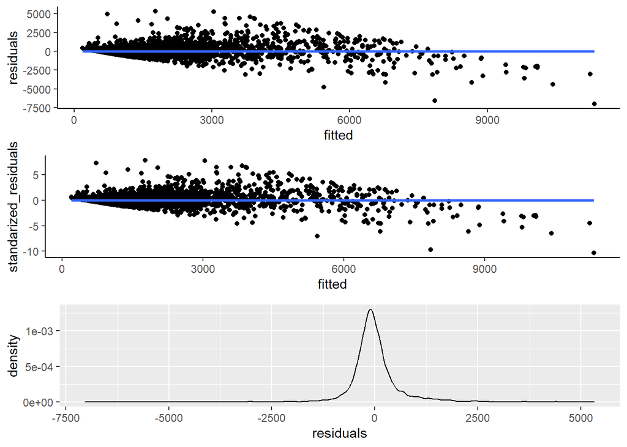

```r
df_diag <- data.frame(residuals = mod2$residuals,
           standarized_residuals = scale(mod2$residuals),
           fitted = mod2$fitted.values)

grid.arrange(
  df_diag %>%
    ggplot(aes(x=fitted,y=residuals)) +
    geom_point() +
    geom_smooth(method="lm",se=F)+
    theme_classic(),

  df_diag %>%
    ggplot(aes(x=fitted,y=standarized_residuals)) +
    geom_point() +
    geom_smooth(method="lm",se=F) +
    theme_classic(),

  df_diag %>%
    ggplot(aes(x=residuals)) +
    geom_density()

)
```

##### There is no trend between predicted variables and both non-standarized and standarized residuals but the residuals are not normally distributed

### Random forest regression

#### First random forest model

```r
train_dummies <-fastDummies::dummy_cols(train_set[,c(1,3,4)], remove_first_dummy = TRUE, remove_selected_columns = TRUE)

train_dummies <- cbind(train_dummies,train_set[,-c(1,3,4)])

test_dummies <- fastDummies::dummy_cols(test_set[,c(1,3,4)],remove_first_dummy = TRUE, remove_selected_columns = TRUE)

test_dummies <- cbind(test_dummies,test_set[,-c(1,3,4)])
```

```r
train_dummies <- janitor::clean_names(train_dummies)
test_dummies <- janitor::clean_names(test_dummies)
```

```r
rf_mod1 <- randomForest::randomForest(avg_salary ~.,ntree=100,importance=TRUE,data=train_dummies,
                                      mtry = floor(sqrt(ncol(train_dummies))))
```

```r
rf_mod1
```

```
##
## Call:
##  randomForest(formula = avg_salary ~ ., data = train_dummies,      ntree = 100, importance = TRUE, mtry = floor(sqrt(ncol(train_dummies))))
##                Type of random forest: regression
##                      Number of trees: 100
## No. of variables tried at each split: 5
##
##           Mean of squared residuals: 352286
##                     % Var explained: 83.93
```

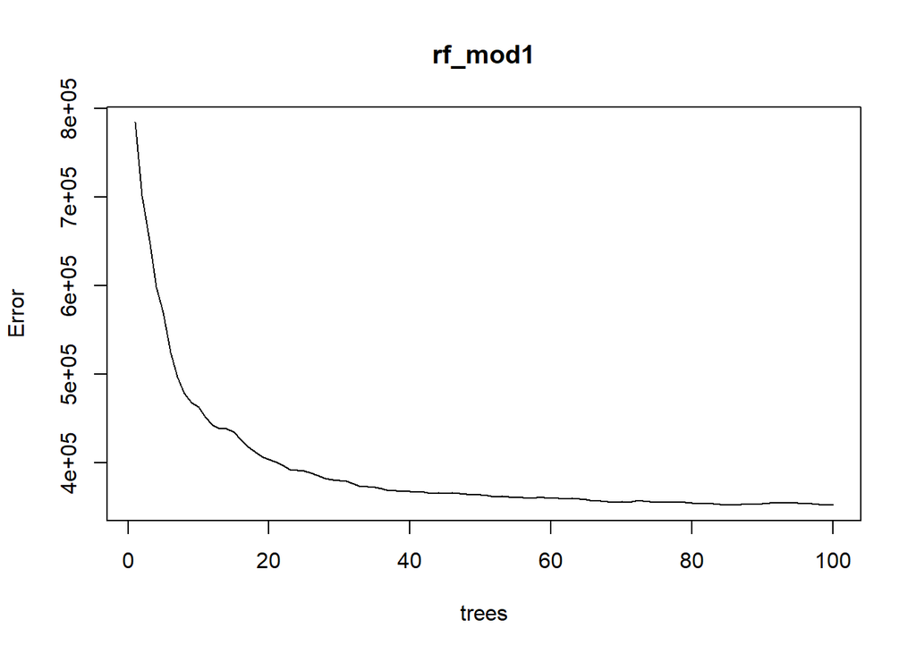

```r
plot(rf_mod1)
```

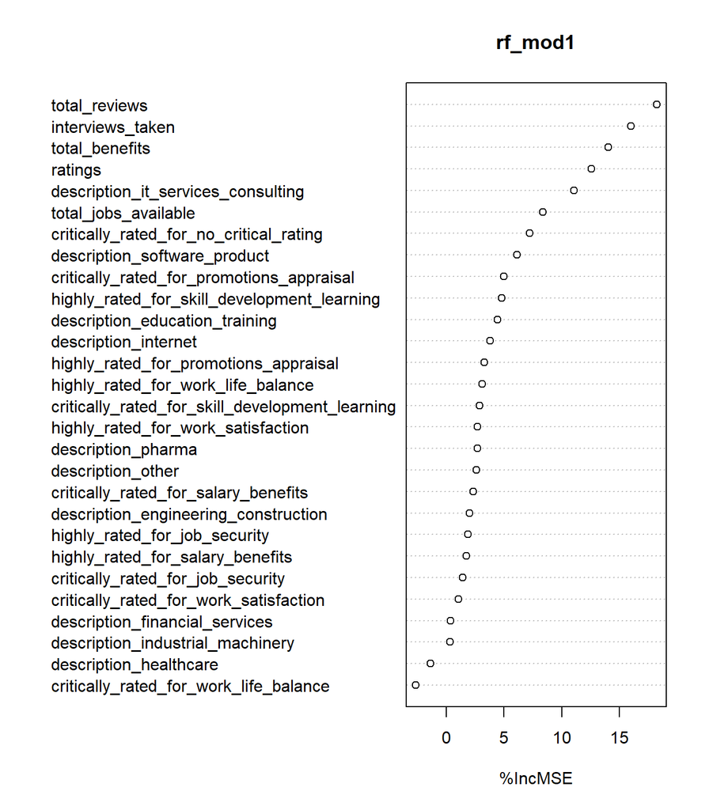

```r
varImpPlot(rf_mod1,type=1)
```

##### Some variables have negative or close to 0 %IncMSE (interpretation is as follows: how would MSE increase if we dropped a variable), so the model might be reduced